# Reproducible Research: Peer Assessment 1

## Loading and preprocessing the data

##### 1. Load the data (i.e. read.csv())

##### 2. Process/transform the data (if necessary) into a format suitable for your analysis

## What is mean total number of steps taken per day?

##### 1. Make a histogram of the total number of steps taken each day

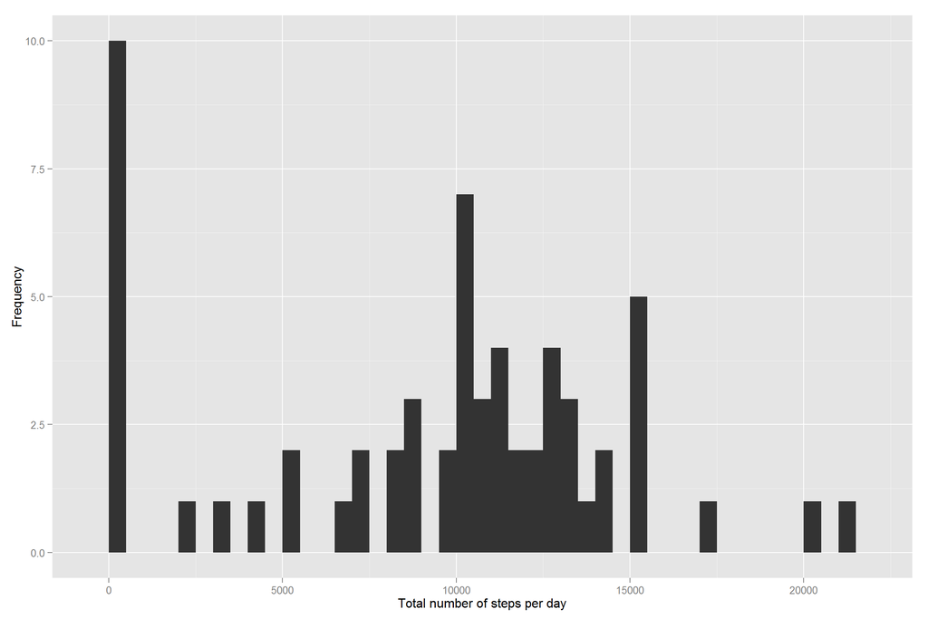

##### 2. Calculate and report the mean and median total number of steps taken per day

We get:

Mean: 9354.2295082

Median: 10395

## What is the average daily activity pattern?

##### 1. Make a time series plot

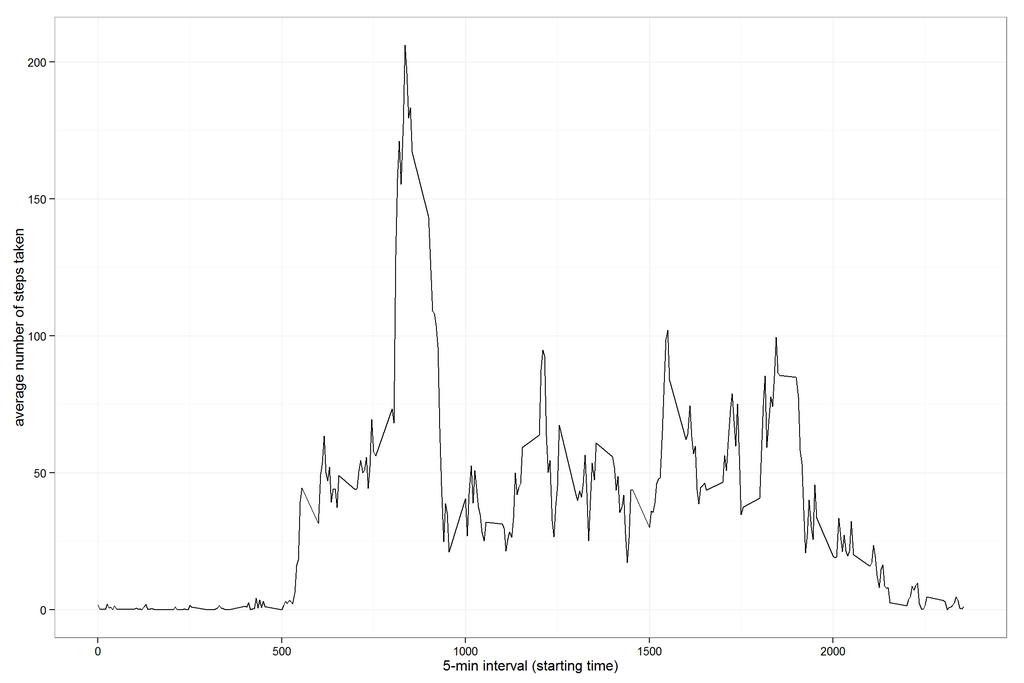

##### 2. Which 5-minute interval, on average across all the days in the dataset, contains the maximum number of steps?

Most steps taken during the 5 minute interval starting at time: 835

## Imputing missing values

##### 1. Calculate and report the total number of missing values in the dataset

Number of missing values: 2304

##### 2. Devise a strategy for filling in all of the missing values in the dataset.

We shall replace with missing values with the mean of the steps taken over all days.

##### 3. Create a new dataset that is equal to the original dataset but with the missing data filled in.

##### 4. Make a histogram of the total number of steps taken each day

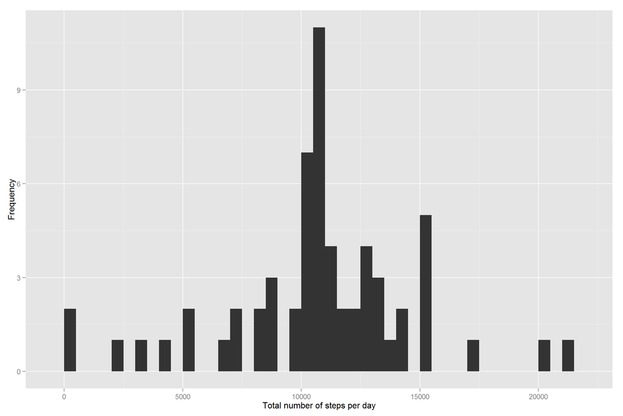

##### … and Calculate and report the mean and median total number of steps taken per day.

Mean: 10766

Median: 10766

## Are there differences in activity patterns between weekdays and weekends?

##### 1. Create a new factor variable in the dataset with two levels - “weekday” and “weekend” indicating whether a given date is a weekday or weekend day.

##### 2. Make a panel plot containing a time series plot

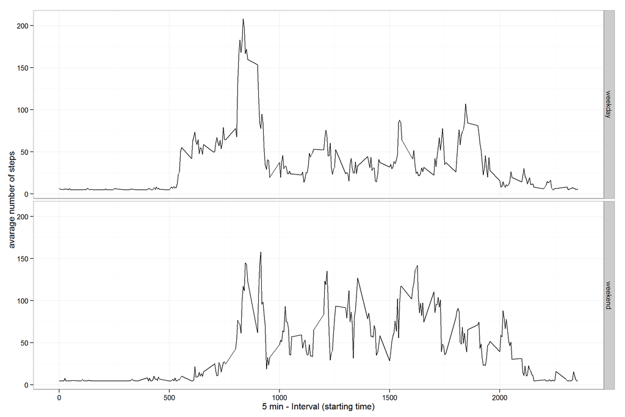

Yes there are differences, people get out of bed later during weekends, and move more during the day(presumably they sit still more during working hours).